# Feature Extraction (Statement Length)

[return to overview page]

The first features we are going to extract are very simple features which relate to the length of statements. These features are very easy to extract and may may provide some cue about the veracity of a statement. In order to avoid being found out, people may give shorter and less detailed responses when they are lying. DePaulo, Lindsay, Malone, Muhlenbruck, Charlton, & Cooper (2003) review evidence from 120 studies about 158 different cues to deception. They find some evidence that liars are less “forthcoming” than truth-tellers (Table 3, p. 91; reproduced below). For example, liars spend significantly less time talking than truth-tellers (d = -0.35). They also provide significantly fewer details when they respond (d = -0.30). Although, the authors find no significant differences between liars and truth-tellers and liars in response length per se. Nevertheless, because people seem to provide less information in various ways when lying than when telling the truth, it is worth trying to extract some proxy for this in our present dataset – which may be provided by various measures of statement length.

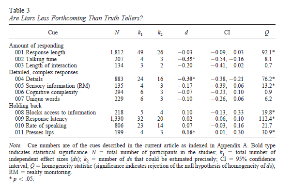

# Packages

Again, I will start by loading relevant packages.

```r
library(tidyverse) # cleaning and visualization
library(quanteda) # text analysis
```

# Load Data

Again, since this is a new analysis, I must load in the data that will be analyzed. This will be the cleaned tabular data structure I created just earlier in Feature Extraction (Overview).

```r
# this loads: stats_clean (a data-frame of out cleaned statements)
load("stats_clean.Rda")
```

# Number of words

## Number of words (example)

I am now going to go through each of the statements and count the number of words in each statement.

I will begin with an example on a single sentence, just for illustration. The sentence I will use will be “Ithaca can get very cold in the winter”, a sentence with eight words. By applying the ntoken() function from the quanteda package, we can count the number of words in this sentence, as show below.

```r
# Create sentence
example_sent <- c("Ithaca can get very cold in the winter.")
print(example_sent)
```

```
## [1] "Ithaca can get very cold in the winter."
```

```r
# Extract number of words in sentence
n_words_example <-
  ntoken(x = example_sent,
         remove_punct = TRUE) # remove punctuation when counting words

# Print output
print(paste("# words in sentence = ",
            as.integer(n_words_example),
            sep = ""))
```

```
## [1] "# words in sentence = 8"
```

## Number of words (full dataset)

We will now simply apply this function to all of the 5004 statements in our dataset, and this will give us a count for the number of words in each statement!

```r
# store results in new column in the stats_clean2 data frame
stats_clean$n_words <-
  ntoken(x = stats_clean$statement,
         remove_punct = TRUE)
```

## Number of words (results)

Let’s take a look at what this gives us.

### Histogram

Across all our statements, here’s what the distribution of word lengths looks like. From examining this histogram, it looks like most sentences have about 40-100 words, but a few sentences have many more words. Thus distribution is definitely skewed. We will just note that for now. (We may later transform this data, to adjust that skew, when building various models.)

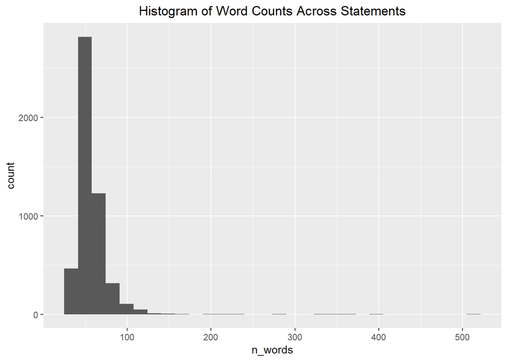

```r
ggplot(data = stats_clean,
       aes(x = n_words)) +
  geom_histogram() +
  labs(title = "Histogram of Word Counts Across Statements") +
  theme(plot.title = element_text(hjust = 0.5))
```

### Empirical Cumulative Distribution

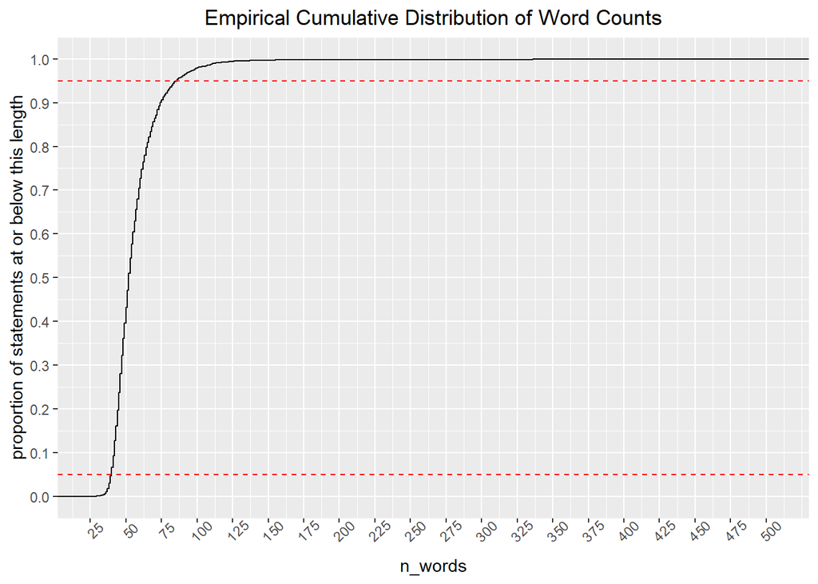

```r
ggplot(data = stats_clean,
       aes(x = n_words)) +
  stat_ecdf(geom = "step") +
  labs(y = "proportion of statements at or below this length",
       title = "Empirical Cumulative Distribution of Word Counts") +
  scale_y_continuous(breaks = seq(from = 0,
                                  to = 1.0,
                                  by = 0.1)) +
  scale_x_continuous(breaks = seq(from = 0,
                                  to = 500,
                                  by = 25)) +
  geom_hline(yintercept = 0.05,
             color = "red",
             linetype = "dashed") +
  geom_hline(yintercept = 0.95,
             color = "red",
             linetype = "dashed") +
  theme(plot.title = element_text(hjust = 0.5),
        axis.text.x = element_text(angle = 45))
```

### Exact Percentiles

In fact, we can compute the percentiles more exactly. Here are the number of words at the following percentiles: 1%, 5%, 25%, 50%, 75%, 95%, 99%.

```r
data.frame(
  quantile(stats_clean$n_words,
         probs = c(0.01,
                   0.05,
                   0.25,
                   0.50,
                   0.75,
                   0.95,
                   0.99))) %>%
  rename_at(1, ~ "n_words")
```

|  | n_words |
| --- | --- |
| 1% | 36 |
| 5% | 40 |
| 25% | 46 |
| 50% | 52 |
| 75% | 62 |
| 95% | 86 |
| 99% | 112 |

### Long Statements

So what are those really long statments? Let’s have a look. I am going to arrange the statements by number of words, starting with the longest ones first. From looking at this output, we can note two things. First, there are really just a handful of statements that are way outside of the norm. And second, the extraordinarily long responses seem to be genuine responses where the participant simply just wrote a lot.

```r
stats_clean %>%
  arrange(desc(n_words)) %>%
  select(n_words,
         statement)
```

| n_words | statement |
| --- | --- |
| 506 | something in my life that i definitely regret and wish i had done differently has got to be the first car that i bought. i had worked so hard to save my money up until i had two thousand dollars and i… |
| 400 | i met mmd in junior high. i was walking to math class pretty quickly as i was running late because i had been tearing my locker and backpack apart looking for my binder, which apparently i had left it… |
| 362 | yesterday i was engaged in when selecting suppliers was for purchasing multiple industrial grade freezers for storing ice-cream for our ice cream and gelato manufacturing business. selecting the right… |
| 357 | something i am good at is that i have a great memory. for example i remember\nthe first time i lived abroad was when i was young and living in india. i was born in america, but my family is from india… |
| 349 | yesterday i woke up around 9:30am, which was a little bit later than usual but it was my day off so i got to sleep in about an hour longer. i laid in bed for about 15 minutes just giving myself time t… |
| 336 | one of my biggest regrets what when i was working as a sales assistant in a clothing department in major east coast city. the clothing department was responsible for providing high quality fashion ite… |
| 285 | i was working as a research assistant in a neuropsychology department in a major east coast city. the neuropsychology department was responsible for providing psychological rehabilitation for brain in… |
| 231 | yesterday i got up for work as usual, ate a quick breakfast, brushed my teeth and got dressed and then i rushed out the door. when i finally got to work everyone was in a really bad mood for no reason… |
| 210 | yesterday i was at a track meet for my college team. i am a varsity, division 1 athlete from college. yesterday i made it to the final lap of 10k race when i was on the track team. i was competing aga… |
| 194 | that's easy...weight training. it's like therapy and religion all in one for me. no matter what is bothering me, it just melts away whenever i walk into my gym...i always feel better after a workout. … |

[output cut: 4994 more lines]

### Word length by question

And how do the word counts vary by the specific question participants are responding to? Let’s examine that here. (I am going to filter out the handful or responses that are extremely long, above 150 words, so that the x-axis of the distributions aren’t so long that the distributions can’t really be compared visually.) In the histograms below, we see that there aren’t any gargantuan differences in the word count distributions between questions.

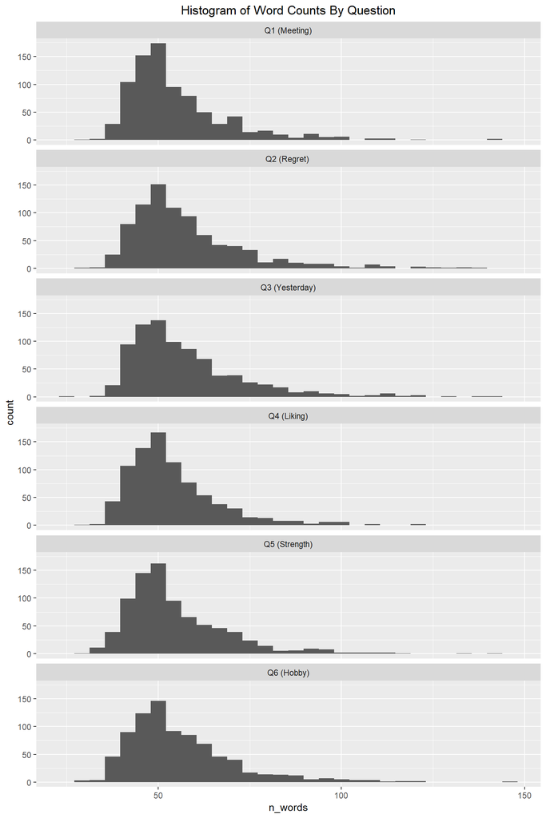

```r
stats_clean %>%
  filter(n_words < 150) %>%
  mutate(q_num = factor(q_num,
                        labels = c("Q1 (Meeting)",
                                   "Q2 (Regret) ",
                                   "Q3 (Yesterday)",
                                   "Q4 (Liking)",
                                   "Q5 (Strength)",
                                   "Q6 (Hobby)"))) %>%
  ggplot(aes(x = n_words)) +
  geom_histogram() +
  labs(title = "Histogram of Word Counts By Question") +
  facet_wrap( ~ q_num,
              ncol = 1) +
  theme(plot.title = element_text(hjust = 0.5))
```

# Unique Words

I am also going to compute two other basic count metrics. One is the number of unique words in each statement (i.e. the sentence “This sentence has many, many many redundant words.” has 8 words, and 6 unique words). And the second is a metric derived from this which is the proportion of unique words in each statement (i.e. number of unique words / total number of words).

## Unique Words (Example)

Again, here is an example for illustrative purposes.

```r
# Create sentence
example_sent2 <- c("This sentence has many, many many redundant words")
print(example_sent2)
```

```
## [1] "This sentence has many, many many redundant words"
```

```r
# ntype() is also from the quanteda package and counts unique tokens
n_unique_example <-
  ntype(x = example_sent2,
        remove_punct = TRUE) # remove punctuation again

# Print output
print(paste("# unique words in sentence = ",
            as.integer(n_unique_example),
            sep = ""))
```

```
## [1] "# unique words in sentence = 6"
```

## Unique Words (Full Dataset)

And now let’s apply this to all 5004 statements (that is, extract both the number of unique words for each statement, and the proportion of unique words in each statement).

```r
# count unique words in each statement
stats_clean$n_unique <-
  ntype(stats_clean$statement,
        remove_punct = TRUE)

# calculate proportion of unique words in each statment
stats_clean <-
  stats_clean %>%
  mutate(n_uniq_prop = n_unique / n_words)

# display result
stats_clean %>%
  select(stat_id,
         n_unique,
         n_uniq_prop,
         statement)
```

| stat_id | n_unique | n_uniq_prop | statement |
| --- | --- | --- | --- |
| 2547 | 38 | 0.7307692 | nathan and i met while i was working as a big brother at the local ymca. nathan was a new hire, and i was assigned to show him the ropes and how we did things at this ymca facility, nathan's outgoing … |
| 385 | 40 | 0.8000000 | i met ml from school. i met him in the 8th grade when we had math class together with mr. walker. we both like to laugh alot and make jokes, so we have plenty in common. me and him would hang out afte… |
| 336 | 45 | 0.7031250 | we met at a a football game in college. he was friends with a few of my friends. we all had a good time and cooked a bunch of food outside the stadium. we all went out after the game with some girls w… |
| 2633 | 37 | 0.8222222 | i met lp at an investment conference in san francisco. he was working with a new startup investment firm that was touting it's new philosophy. he was recruiting new investors and buying drinks and din… |
| 2797 | 35 | 0.7608696 | i was at the bar with a group of my friends. he was a mutual aquatint to a close friend of mine. i had met him several times before, and this was the first time we had really hung out and talked. we b… |
| 2746 | 32 | 0.7619048 | i mwt her in penn station 20 years ago. we were both waiting for trains and started to talk. i later met her brother and started to date him. i married him. cm and i are still good friends to this day… |
| 2735 | 62 | 0.6739130 | i met db when i had just come off stage from a concert at the local fair. he was a scout who booked musical groups to work for a small performing arts company in a larger city in my state. he said he … |
| 2880 | 40 | 0.7272727 | i met her in high school. she was friends with a few people from band. since i was in the marching band, i made friends with them, and they invited me to be a part of their group. mp and i got along w… |
| 2690 | 31 | 0.7209302 | we met a grocery store. they were in line behind me and we were talking about some sale items. then, we were talking about living in the same area of town and came to find out that we lived in the sam… |
| 2602 | 40 | 0.7017544 | i met them a strip club and it was something cool, because they were a stripper and i saw them another day and decided to talk to them and we made good conversation outside of their work and for that … |

[output cut: 4994 more lines]

## Save output

Again, we can now save the cleaned output (as an R data object), for future import and use in subsequent analyses.

```r
# create object just with stat_id and newly created length variables
stats_length <-
  stats_clean %>%
  select(stat_id,
         n_words,
         n_unique,
         n_uniq_prop)

# save that object
save(stats_length,
     file = "stats_length.Rda")

# now remove stats_clean from global environment (to avoid later confusion)
rm(stats_clean)
```

# Citations

- DePaulo, B. M., Lindsay, J. J., Malone, B. E., Muhlenbruck, L., Charlton, K., & Cooper, H. (2003). Cues to deception. Psychological Bulletin, 129(1), 74.